# Tidy Data

Paul Oldham

19 August 2015

In this chapter we will use RStudio to prepare patent data for visualisation in an infographic using online software tools.

Infographics are a popular way of presenting data in a way that is easy for a reader to understand without reading a long report. Infographics are well suited to presenting summaries of data with simple messages about key findings. A good infographic can encourage the audience to read a detailed report and is a tool for engagement with audiences during presentations of the findings of patent research.

Some patent offices have already been creating infographics as part of their reports to policy makers and other clients. The Instituto Nacional de Propiedade Industrial (INPI) in Brazil produces regular two page [Technology Radar](http://www.inpi.gov.br/menu-servicos/informacao/radares-tecnologicos) (Radar Tecnologico) consisting of charts and maps that briefly summarise more detailed research on subjects such as [Nanotechnology in Waste Management](http://www.inpi.gov.br/menu-servicos/arquivos-cedin/n08_radar_tecnologico_nano_residuos_versao_resumida_ingles_atualizada_20160122.pdf). [WIPO Patent Landscape Reports](http://www.wipo.int/patentscope/en/programs/patent_landscapes/), which go into depth on patent activity for a particular area, are accompanied by one page infographics that have proved very popular such as the infographic accompanying a recent report on [assistive devices](http://www.wipo.int/export/sites/www/patentscope/en/programs/patent_landscapes/reports/documents/assistivedevices_infographic.pdf).

A growing number of companies are offering online infographic software services such as [infogr.am](https://infogr.am/app/#/library),easel.ly [piktochart.com](https://magic.piktochart.com/templates), [canva.com](https://www.canva.com/create/infographics/) or venngage.com to mention only a selection of the offerings out there. The [Cool Infographics website](http://www.coolinfographics.com/tools/) provides a useful overview of available tools.

One feature of many of these services is that they are based on a freemium model. Creating graphics is free but the ability to export files and the available formats for export of your masterpiece (e.g. high resolution or .pdf) often depend on upgrading to a monthly account at varying prices. In this chapter we test drive [infogr.am](https://infogr.am/app/#/library) as a chart friendly service, albeit with export options that depend on a paid account.

This chapter is divided into two sections.

1. In part 1 we focus on using RStudio to prepare patent data for visualisation in infographics software using the `dplyr`, `tidyr` and `stringr` packages. This involves dealing with common problems with patent data such as concatenated fields, white space and creating counts of data fields.
2. In part 2 we produce an infographic from the data using [infogr.am](https://infogr.am/app/#/library).

## Getting Started

To start with we need to ensure that RStudio and R for your operating system are installed by following the instructions on the RStudio website [here](https://www.rstudio.com/products/rstudio/download/). Do not forget to follow the link to also [install R for your operating system](https://cran.rstudio.com).

When working in RStudio it is good practice to work with projects. This will keep all of the files for a project in the same folder. To create a project go to File, New Project and create a project. Call the project something like infographic. Any file you create and save for the project will now be listed under the Files tab in RStudio.

R works using packages (libraries) and there are around 7,490 of them for a whole range of purposes. We will use just a few of them. To install a package we use the following. Copy and paste the code into the Console and press enter.

```r
install.packages("readr")  # read in .csv files `readxl` for excel files
install.packages("dplyr")  # wrangle data
install.packages("tidyr")  # tidy data
install.packages("stringr")  # work with text strings
install.packages("ggplot2")  # for graphing
```

Packages can also be installed by selecting the Packages tab and typing the name of the package.

To load the package (library) use the following or check the tick box in the Packages pane.

```r
library(readr)
library(dplyr)
library(tidyr)
library(stringr)
library(ggplot2)
```

We are now ready to go.

## Load a .csv file using `readr`

We will work with the `pizza_medium_clean` dataset in the online [Github Manual repository](https://github.com/poldham/opensource-patent-analytics/tree/master/2_datasets). If manually downloading a file remember to click on the file name and select `Raw` to download the actual file.

We can use the easy to use `read_csv()` function from the `readr` package to quickly read in our pizza data directly from the Github repository. Note the `raw` at the beginning of the filename.

```r
pizza <- read_csv("https://raw.githubusercontent.com/poldham/opensource-patent-analytics/master/2_datasets/pizza_medium_clean/pizza.csv")
```

`readr` will display a warning for the file arising from its efforts to parse publication dates on import. We will ignore this as we will not be using this field.

As an alternative to importing directly from Github download the file and enter the path in quotes (you must use the full path, e.g. C: etc.). For additional arguments (controls) look up the help for the function using `?read_csv`.

```r
pizza_read <- read_csv("yourfilepath")
```

`readr` and `readxl` (for Excel files) are quite new. For more complex data see the Manual articles on [reading csv files in R](http://poldham.github.io/reading-csv-files-in-R/) and [read excel files in R`](http://poldham.github.io/reading-writing-excel-files-R/) packages for importing Excel.

## Viewing Data

We can view data in a variety of ways.

1. In the console:

```r
pizza
```

```
## Source: local data frame [9,996 x 31]
##
##                                                             applicants_cleaned
##                                                                          (chr)
## 1                                                                           NA
## 2  Ventimeglia Jamie Joseph; Ventimeglia Joel Michael; Ventimeglia Thomas Jose
## 3                                             Cordova Robert; Martinez Eduardo
## 4                                                      Lazarillo De Tormes S L
## 5                                                                           NA
## 6                                                           Depoortere, Thomas
## 7                                                             Frisco Findus Ag
## 8                                                   Bicycle Tools Incorporated
## 9                                                           Castiglioni, Carlo
## 10                                                                          NA
## ..                                                                         ...
## Variables not shown: applicants_cleaned_type (chr),
##   applicants_organisations (chr), applicants_original (chr),
##   inventors_cleaned (chr), inventors_original (chr), ipc_class (chr),
##   ipc_codes (chr), ipc_names (chr), ipc_original (chr), ipc_subclass_codes
##   (chr), ipc_subclass_detail (chr), ipc_subclass_names (chr),
##   priority_country_code (chr), priority_country_code_names (chr),
##   priority_data_original (chr), priority_date (chr),
##   publication_country_code (chr), publication_country_name (chr),
##   publication_date (date), publication_date_original (chr),
##   publication_day (int), publication_month (int), publication_number
##   (chr), publication_number_espacenet_links (chr), publication_year (int),
##   title_cleaned (chr), title_nlp_cleaned (chr),
##   title_nlp_multiword_phrases (chr), title_nlp_raw (chr), title_original
##   (chr)
```

2. In Environment click on the blue arrow to see in the environment. Keep clicking to open a new window with the data.
3. Use the `View()` command (for data.frames and tables)

```r
View(pizza)
```

If possible use the View() command or environment. The difficulty with the console is that large amounts of data will simply stream past.

## Identifying Types of Object

We often want to know what type of object we are working with and more details about the object so we know what to do later. Here are some of the most common commands for obtaining information about objects.

```r
class(pizza)  ## type of object
names(pizza)  ## names of variables
str(pizza)  ## structure of object
dim(pizza)  ## dimensions of the object
```

The most useful command in this list is `str()` because this allows us to access the structure of the object and see its type.

```r
str(pizza)
```

```
## Classes 'tbl_df', 'tbl' and 'data.frame':    9996 obs. of  31 variables:
##  $ applicants_cleaned                : chr  NA "Ventimeglia Jamie Joseph; Ventimeglia Joel Michael; Ventimeglia Thomas Joseph" "Cordova Robert; Martinez Eduardo" "Lazarillo De Tormes S L" ...
##  $ applicants_cleaned_type           : chr  "People" "People" "People" "Corporate" ...
##  $ applicants_organisations          : chr  NA NA NA "Lazarillo De Tormes S L" ...
##  $ applicants_original               : chr  NA "Ventimeglia Jamie Joseph;Ventimeglia Thomas Joseph;Ventimeglia Joel Michael" "Cordova Robert;Martinez Eduardo" "LAZARILLO DE TORMES S L" ...
##  $ inventors_cleaned                 : chr  "Sanchez Zarzoso, Maria Isabel" "Ventimeglia Jamie Joseph; Ventimeglia Joel Michael; Ventimeglia Thomas Joseph" "Cordova Robert; Martinez Eduardo" "Sanchez Zarzoso, Maria Isabel" ...
##  $ inventors_original                : chr  "Sanchez Zarzoso Maria Isabel" "Ventimeglia Jamie Joseph;Ventimeglia Thomas Joseph;Ventimeglia Joel Michael" "Cordova Robert;Martinez Eduardo" "Sanchez Zarzoso Maria Isabel" ...
##  $ ipc_class                         : chr  "A21: Baking; A23: Foods Or Foodstuffs" "A21: Baking" "A21: Baking" "A21: Baking; A23: Foods Or Foodstuffs" ...
##  $ ipc_codes                         : chr  "A21D 13/00; A23L 1/16" "A21B 3/13" "A21C 15/04" "A21D 13/00; A23L 1/16" ...
##  $ ipc_names                         : chr  "A21D 13/00: Finished or partly finished bakery products; A23L 1/16: Foods or foodstuffs; Their preparation or treatment -> cont"| __truncated__ "A21B 3/13: Parts or accessories of ovens -> Baking-tins; Baking forms" "A21C 15/04: Apparatus for handling …
##  $ ipc_original                      : chr  "A21D 13/00;A21D 13/00;A23L 1/16;A23L 1/16" "A21B 3/13" "A21C 15/04" "A21D 13/00;A23L 1/16" ...
##  $ ipc_subclass_codes                : chr  "A21D; A23L" "A21B" "A21C" "A21D; A23L" ...
##  $ ipc_subclass_detail               : chr  "A21D: Treatment, E.G. Preservation, Of Flour Or Dough For Baking, E.G. By Addition Of Materials; A23L: Foods, Foodstuffs, Or No"| __truncated__ "A21B: Bakers' Ovens" "A21C: Machines Or Equipment For Making Or Processing Doughs" "A21D: Treatment, E.G. P…
##  $ ipc_subclass_names                : chr  "A21D: Baking; Equipment For Making Or Processing Doughs; Doughs For Baking -> Treatment, E.G. Preservation, Of Flour Or Dough F"| __truncated__ "A21B: Baking; Equipment For Making Or Processing Doughs; Doughs For Baking -> Bakers' Ovens; Machines Or Eq…
##  $ priority_country_code             : chr  "ES" NA NA "ES" ...
```

[output cut: 22 more lines]

`str()` is particularly useful because we can see the names of the fields (vectors) and their type. Most patent data is a character vector with dates forming integers.

## Working with Data

We will often want to select aspects of our data to focus on a specific set of columns or to create a graph. We might also want to add information, notably numeric counts.

The `dplyr` package provides a set of very handy functions for selecting, adding and counting data. The `tidyr` and `stringr` packages are sister packages that contain a range of other useful functions for working with our data. We have covered some of these in other chapters on graphing using R but will go through them quickly and then pull them together into a function that we can use across our dataset.

### Select

In this case we will start by using the `select()` function to limit the data to specific columns. We can do this using their names or their numeric position (best for large number of columns e.g. 1:31). In `dplyr`, unlike most R packages, existing character columns do not require `""`.

```r
pizza_number <- select(pizza, publication_number, publication_year)
```

We now have a new data.frame that contains two columns. One with the year and one with the publication number. Note that we have created a new object called pizza_number using `<-` and that after `select()` we have named our original data and the columns we want. A fundamental feature of select is that it will drop columns that we do not name. So it is best to create a new object using `<-` if you want to keep your original data for later work.

### Adding data with `mutate()`

`mutate()` is a `dplyr` function that allows us to add data based on existing data in our data frame, for example to perform a calculation. In the case of patent data we normally lack a numeric field to use for counts. We can however assign a value to our publication field by using sum() and the number 1 as follows.

```r
pizza_number <- mutate(pizza_number, n = sum(publication_number = 1))
```

When we view `pizza_number` we now have a value of 1 in the column `n` for each publication number. Note that in patent data a priority, application, publication or family number may occur multiple times and we would want to reduce the dataset to distinct records. For that we would use `n_distinct(pizza_number$publication_number)` from `dplyr` or `unique(pizza_number$publication_number)` from base R. Because the publication numbers are unique we can proceed.

### Counting data using `count()`

At the moment, we have multiple instances of the same year (where a patent publication occurs in that year). We now want to calculate how many of our documents were published in each year. To do that we will use the `dplyr` function `count()`. We will use the publication_year and add `wt =` (for weight) with `n` as the value to count.

```r
pizza_total <- count(pizza_number, publication_year, wt = n)
pizza_total
```

```
## Source: local data frame [58 x 2]
##
##    publication_year     n
##               (int) (dbl)
## 1              1940     1
## 2              1954     1
## 3              1956     1
## 4              1957     1
## 5              1959     1
## 6              1962     1
## 7              1964     2
## 8              1966     1
## 9              1967     1
## 10             1968     8
## ..              ...   ...
```

When we now examine pizza_total, we will see the publication year and a summed value for the records in that year.

This raises the question of how we know that R has calculated the count correctly. We already know that there are 9996 records in the pizza dataset. To check our count is correct we can simply use sum and select the column we want to sum using `$`.

```r
sum(pizza_total$n)
```

```
## [1] 9996
```

So, all is good and we can move on. The `$` sign is one of the main ways of subsetting to tell R that we want to work with a specific column (the others are “[” and “[[”).

### Renaming a field using `rename()`

```r
pizza_total <- rename(pizza_total, pubyear = publication_year, publications = n)
```

### Make a quickplot with `qplot()`

Using the `qplot()` function in `ggplot2` we can now draw a quick line graph. Note that qplot() is unusual in R because the data (pizza_total) appears after the coordinates. We will specify that we want a line using `geom =` (if geom is left out it will be a scatter plot). This will give us an idea of what our plot might look like in our infographic and actions we might want to take on the data.

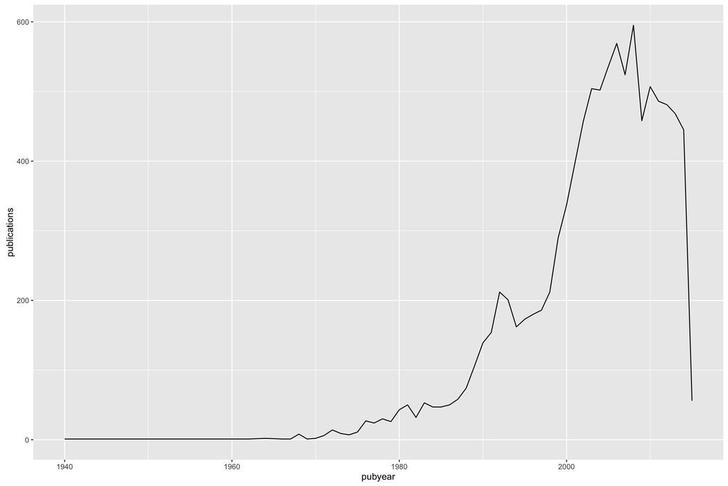

```r
qplot(x = pubyear, y = publications, data = pizza_total, geom = "line")
```

The plot reveals a data cliff in recent years. This normally reflects a lack of data for the last 2-3 years as recent documents feed through the system en route to publication.

It is a good idea to remove the data cliff by cutting the data 2-3 years prior to the present. In some cases two years is sufficient, but 3 years is a good rule of thumb.

We also have long tail of data with limited data from 1940 until the late 1970s. Depending on our purposes with the analysis we might want to keep this data (for historical analysis) or to focus in on a more recent period.

We will limit our data to specific values using the `dplyr` function `filter()`.

For more details on graphing in R see the [qplot](http://poldham.github.io/ggplot_pizza_patents_part1/) and [gglot2](http://poldham.github.io/ggplot_pizza_patents_part2j/) chapters of the manual.

### Filter data using `filter()`

In contrast with `select()` which works with columns, `filter()` in `dplyr` works with rows. In this case we need to filter on the values in the pubyear column. To remove the data prior to 1990 we will use the greater than or equal to operator `>=` on the pubyear column and we will use the less than or equal to `<=` operator on the values after 2012.

One strength of `filter()` in `dplyr` is that it is easy to filter on multiple values in the same expression (unlike the very similar filter function in base R). The use of `filter()` will also remove the 30 records where the year is recorded as NA (Not Available). We will write this file to disk using the simple `write_csv()` from `readr`. To use `write_csv()` we first name our data (`pizza_total`) and then provide a file name with a .csv extension. In this case and other examples below we have used a descriptive file name bearing in mind that Windows systems have limitations on the length and type of characters that can be used in file names.

```r
pizza_total <- filter(pizza_total, pubyear >= 1990, pubyear <= 2012)
write_csv(pizza_total, "pizza_total_1990_2012.csv")
pizza_total
```

```
## Source: local data frame [23 x 2]
##
##    pubyear publications
##      (int)        (dbl)
## 1     1990          139
## 2     1991          154
## 3     1992          212
## 4     1993          201
## 5     1994          162
## 6     1995          173
## 7     1996          180
## 8     1997          186
## 9     1998          212
## 10    1999          290
## ..     ...          ...
```

When we print pizza_total to the console we will see that the data now covers the period 1990-2012. When using `filter()` on values in this way it is important to remember to apply this filter to any subsequent operations on the data (such as applicants) so that it matches the same data period.

To see our .csv file we can head over to the Files tab and, assuming that we have created a project, the file will now appear in the list of project files. Clicking on the file name will display the raw unformatted data in RStudio.

### Simplify code using pipes `%>%`

So far we have handled the code one line at a time. But, one of the great strengths of using a programming language is that we can run multiple lines of code together. There are two basic ways that we can do this.

We will create a new temporary object `df` to demonstrate this.

1. The standard way

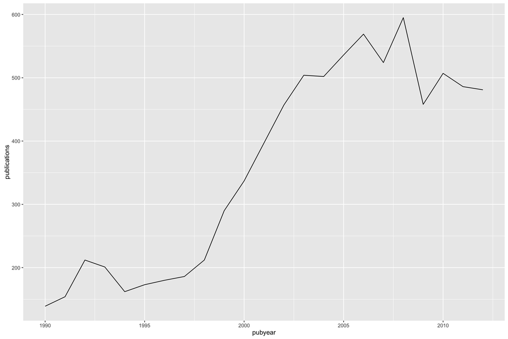

```r
df <- select(pizza, publication_number, publication_year)
df <- mutate(df, n = sum(publication_number = 1))
df <- count(df, publication_year, wt = n)
df <- rename(df, pubyear = publication_year, publications = n)
df <- filter(df, pubyear >= 1990, pubyear <= 2012)
qplot(x = pubyear, y = publications, data = df, geom = "line")
```

The code we have just created is six lines long. If we select all of this code and run it in one go it will produce our graph.

We can save quite a lot of typing and reduce the complexity of the code using the pipe operator introduced by the the `magrittr` package and then adopted in Hadley Wickham’s data wrangling and tidying packages we are using.

2. Using pipes `%>%`

Pipes are now a very popular way of writing R code because they simplify writing R code and speed it up. The most popular pipe is `%>%` which means “this” then “that”. In this case we are going to create a new temporary object `df1` by first applying select to pizza, then mutate, count, rename and filter. Note that we only name our dataset once (in `select()`) and we do not need to keep overwriting the object.

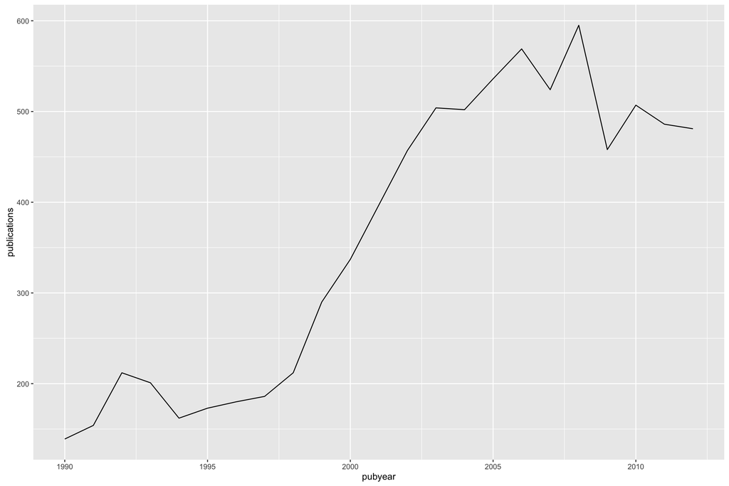

```r
df1 <- select(pizza, publication_number, publication_year) %>% mutate(n = sum(publication_number = 1)) %>%
    count(publication_year, wt = n) %>% rename(pubyear = publication_year, publications = n) %>%
    filter(pubyear >= 1990, pubyear <= 2012) %>% qplot(x = pubyear, y = publications,
    data = ., geom = "line") %>% print()
```

One point to note about this code is that `qplot()` requires us to name our data (in this case `df1`). However, `df1` is actually the final output of the code and does not exist as an input object before the final line is run. So, if we attempt to use `data = df1` in `qplot()` we will receive an error message. The way around this is to use `.` in place of our data object. That way `qplot()` will know we want to graph the outputs of the earlier code. Finally, we need to add an explicit call to `print()` to display the graph (without this the code will work but we will not see the graph).

If we now inspect the structure of the df1 object (using `str(df1)`) in the console, it will be a list. The reason for this is that it is an object with mixed components, including a data.frame with our data plus additional data setting out the contents of the plot. As there is no direct link between R and our infographics software this will create problems for us later because the infographics software won’t know how to interpret the list object. So, it is generally a good idea to use a straight data.frame.

## Harmonising data

One challenge with creating multiple tables from a baseline dataset is keeping track of subdatasets. At the moment we have two basic objects we will be working with:

1. `pizza` - our raw dataset
2. `pizza_total` - created via `pizza_number` limited to 1990_2012.

In the remainder of the chapter we will want to create some additional datasets from our pizza dataset. These are:

1. Country trends
2. Applicants
3. International Patent Classification (IPC) Class
4. Phrases
5. Google
6. Google IPC
7. Google phrases

We need to make sure that any data that we generate from our raw dataset matches the period for the `pizza_total` dataset. If we do not do this there is a risk that we will generate subdatasets with counts for the raw pizza dataset.

To handle this we will use `filter()` to create a new baseline dataset with an unambiguous name.

```r
pizza_1990_2012 <- rename(pizza, pubyear = publication_year) %>% filter(pubyear >=
    1990, pubyear <= 2012) %>% print()
```

```
## Source: local data frame [8,262 x 31]
##
##                    applicants_cleaned applicants_cleaned_type
##                                 (chr)                   (chr)
## 1                                  NA                  People
## 2             Lazarillo De Tormes S L               Corporate
## 3                                  NA                  People
## 4                  Depoortere, Thomas                  People
## 5                    Frisco Findus Ag               Corporate
## 6          Bicycle Tools Incorporated               Corporate
## 7                  Castiglioni, Carlo                  People
## 8                                  NA                  People
## 9               Bujalski, Wlodzimierz                  People
## 10 Ehrno Flexible A/S; Stergaard, Ole       Corporate; People
## ..                                ...                     ...
## Variables not shown: applicants_organisations (chr), applicants_original
##   (chr), inventors_cleaned (chr), inventors_original (chr), ipc_class
##   (chr), ipc_codes (chr), ipc_names (chr), ipc_original (chr),
##   ipc_subclass_codes (chr), ipc_subclass_detail (chr), ipc_subclass_names
##   (chr), priority_country_code (chr), priority_country_code_names (chr),
##   priority_data_original (chr), priority_date (chr),
##   publication_country_code (chr), publication_country_name (chr),
##   publication_date (date), publication_date_original (chr),
##   publication_day (int), publication_month (int), publication_number
##   (chr), publication_number_espacenet_links (chr), pubyear (int),
##   title_cleaned (chr), title_nlp_cleaned (chr),
##   title_nlp_multiword_phrases (chr), title_nlp_raw (chr), title_original
##   (chr)
```

In this case we start with a call to `rename()` to make this consistent with our pizza_total table and then use a pipe to filter the data on the year. Note here that when filtering raw data on a set of values it is important to inspect it first to check that the field is clean (e.g. not concatenated).

We are now in a position to create our country trends table.

## Country Trends using `spread()`

There are two basic data formats: long and wide. Our pizza dataset is in long format because each column is a variable (e.g. publication_country) and each row in `publication_country` contains a country name. This is the most common and useful data format.

However, in some cases, such as infogr.am our visualisation software will expect the data to be in wide format. In this case each country name would become a variable (column name) with the years forming the rows and the number of records per year the observations. The key to this is the `tidyr()` function `spread()`.

As above we will start off by using select() to create a table with the fields that we want. We will then use mutate() to add a numeric field and then count up that data. To illustrate the process run this code (we will not create an object).

```r
select(pizza_1990_2012, publication_country_name, publication_number, pubyear) %>%
    mutate(n = sum(publication_number = 1)) %>% count(publication_country_name,
    pubyear, wt = n) %>% print()
```

```
## Source: local data frame [223 x 3]
## Groups: publication_country_name [?]
##
##    publication_country_name pubyear     n
##                       (chr)   (int) (dbl)
## 1                    Canada    1990    19
## 2                    Canada    1991    49
## 3                    Canada    1992    66
## 4                    Canada    1993    59
## 5                    Canada    1994    50
## 6                    Canada    1995    39
## 7                    Canada    1996    36
## 8                    Canada    1997    45
## 9                    Canada    1998    46
## 10                   Canada    1999    47
## ..                      ...     ...   ...
```

When we run this code we will see the results in long format. We now want to take our `publication_country_name` column and spread it to form columns with `n` as the values.

In using spread note that it takes a data argument (`pizza_1990_2012`), a key (`publication_country_name`), and value column (`n`). We are using pipes so the data only needs to be named in the first line. For additional arguments see ?spread().

```r
country_totals <- select(pizza_1990_2012, publication_country_name, publication_number,
    pubyear) %>% mutate(n = sum(publication_number = 1)) %>% count(publication_country_name,
    pubyear, wt = n) %>% spread(publication_country_name, n) %>% print()
```

```
## Source: local data frame [23 x 17]
##
##    pubyear Canada China Eurasian Patent Organization
##      (int)  (dbl) (dbl)                        (dbl)
## 1     1990     19    NA                           NA
## 2     1991     49    NA                           NA
## 3     1992     66    NA                           NA
## 4     1993     59    NA                           NA
## 5     1994     50    NA                           NA
## 6     1995     39    NA                           NA
## 7     1996     36     1                           NA
## 8     1997     45    NA                           NA
## 9     1998     46    NA                           NA
## 10    1999     47     2                            2
## ..     ...    ...   ...                          ...
## Variables not shown: European Patent Office (dbl), Germany (dbl), Israel
##   (dbl), Japan (dbl), Korea, Republic of (dbl), Mexico (dbl), Patent
##   Co-operation Treaty (dbl), Portugal (dbl), Russian Federation (dbl),
##   Singapore (dbl), South Africa (dbl), Spain (dbl), United States of
##   America (dbl)
```

We now have data in wide format.

In some cases, such as infogr.am, visualisation software may expect the country names as rows and the year as column names. We can modify our call to `spread()` by replacing the `publication_country_name` with `pubyear`. Then we will write the data to disk for use in our infographic.

```r
country_totals <- select(pizza_1990_2012, publication_country_name, publication_number,
    pubyear) %>% mutate(n = sum(publication_number = 1)) %>% count(publication_country_name,
    pubyear, wt = n) %>% spread(pubyear, n) %>% print()
```

```
## Source: local data frame [16 x 24]
## Groups: publication_country_name [16]
##
##        publication_country_name  1990  1991  1992  1993  1994  1995  1996
##                           (chr) (dbl) (dbl) (dbl) (dbl) (dbl) (dbl) (dbl)
## 1                        Canada    19    49    66    59    50    39    36
## 2                         China    NA    NA    NA    NA    NA    NA     1
## 3  Eurasian Patent Organization    NA    NA    NA    NA    NA    NA    NA
## 4        European Patent Office    22    29    36    29    26    29    27
## 5                       Germany     2     2     2     2     5     2     1
## 6                        Israel    NA    NA     1    NA    NA     1     1
## 7                         Japan    NA    NA    NA    NA    NA    NA    NA
## 8            Korea, Republic of    NA    NA    NA     1    NA    NA     1
## 9                        Mexico    NA    NA    NA    NA    NA    NA    NA
## 10   Patent Co-operation Treaty     8    13    31    16    20    22    23
## 11                     Portugal    NA    NA    NA    NA    NA    NA    NA
## 12           Russian Federation    NA    NA    NA    NA    NA    NA    NA
## 13                    Singapore    NA    NA    NA    NA    NA    NA    NA
## 14                 South Africa     2     3     3     3     3     1     9
## 15                        Spain    NA    NA    NA    NA    NA    NA    NA
## 16     United States of America    86    58    73    91    58    79    81
## Variables not shown: 1997 (dbl), 1998 (dbl), 1999 (dbl), 2000 (dbl), 2001
##   (dbl), 2002 (dbl), 2003 (dbl), 2004 (dbl), 2005 (dbl), 2006 (dbl), 2007
##   (dbl), 2008 (dbl), 2009 (dbl), 2010 (dbl), 2011 (dbl), 2012 (dbl)
```

```r
write_csv(country_totals, "pizza_country_1990_2012.csv")
```

To restore the data to long format we would need to use `gather()` as the counterpart to `spread()`. gather takes a dataset, a key for the name of the column we want to gather the countries into, a value for the numeric count (in this case n), and finally the positions of the columns to gather in. Note here that we need to look up the column positions in `country_totals` (e.g. using `View()`).

```r
gather(country_totals, country, n, 2:17) %>% print()
```

[output not shown]

The combination of spread and gather work really well to prepare data into formats that are expected by other software. However, one of the main issues we encounter with patent data is that our data is not tidy because various fields are concatenated.

## Tidying data - Separating and Gathering

In patent data we often see concatenated fields with a separator (normally a `;`). These are typically applicant names, inventor names, IPC codes, or document numbers (priority numbers, family numbers). We need to `tidy` this data prior to data cleaning (such as cleaning names) or to prepare for analysis and visualisation. For more on the concept of tidy data read [Hadley Wickham’s Tidy Data article](http://vita.had.co.nz/papers/tidy-data.pdf)

To tidy patent data we will typically need to do two things.

1. Separate the data so that each cell contains a unique data point (e.g. a name, code or publication number). This normally involves separating data into columns.
2. Gathering the data back in. This involves transforming the data in the columns we have created into rows.

Separating data into columns is very easy in tools such as Excel. However, gathering the data back in to separate rows is remarkably difficult. Happily, this is very easy to do in R with the `tidyr` package.

The `tidyr` package contains two functions that are very useful when working with patent data. The first of these is `separate()`.

Here we will work with the `applicants_cleaned` field in the pizza dataset. This field contains concatenated names with a `;` as the separator. For example, on lines 1_9 there are single applicant names or NA values. However, on lines 10 and line 59 we see:

Ehrno Flexible A/S; Stergaard, Ole Farrell Brian; Mcnulty John; Vishoot Lisa

The problem here is that when we are dealing with thousands of lines of applicant names we don’t know how many names might be concatenated into each cell as a basis for separating the data into columns.

The first option we will try is to separate the `applicants_cleaned` field into an arbitrarily high number of columns.

### Separate

In the first step we use the tidyr `separate()` function. Ideally the field we want to separate is the first column because we will be using the numeric positions of the columns. In the case of the pizza1 data the `applicants_cleaned` field is already the first column. If we wanted to move a column to the first position we could use select() as follows. To illustrate this we will create two new temporary objects, p1 and p2.

```r
p1 <- select(pizza, 2:31, 1)  #moves column 1 to the end (column 31)
p2 <- select(p1, 31, 1:30)  #moves column 31 to the first column
```

If we print p1 to the console `applicants_cleaned` will now appear as the final column. If we print p2 it will have been restored to the first column. Working with the numeric positions of columns can take a little while to get used to but in the first code chunk we are saying columns 2 to 31 and then column 1. In the second chunk we reverse this to say column 31 and then columns 1:30.

Next we use `separate()` on `pizza_1990_2012`. This is followed by the unquoted name of the column we want to separate and the number of columns we want to separate the applicants into (1:30). Here we have chosen an arbitrary 30 columns. We then specify the separator with the `;`. The next two arguments are for what to do with any extra data and the direction to fill cells. We use `fill = "right"` because `separate()` will throw an error if the cells do not divide into the same number of pieces.

```r
pizza1 <- separate(pizza_1990_2012, applicants_cleaned, 1:30, sep = ";", extra = "merge",
    fill = "right") %>% print()
```

```
## Source: local data frame [8,262 x 60]
##
##                             1               2     3     4     5     6
##                         (chr)           (chr) (chr) (chr) (chr) (chr)
## 1                          NA              NA    NA    NA    NA    NA
## 2     Lazarillo De Tormes S L              NA    NA    NA    NA    NA
## 3                          NA              NA    NA    NA    NA    NA
## 4          Depoortere, Thomas              NA    NA    NA    NA    NA
## 5            Frisco Findus Ag              NA    NA    NA    NA    NA
## 6  Bicycle Tools Incorporated              NA    NA    NA    NA    NA
## 7          Castiglioni, Carlo              NA    NA    NA    NA    NA
## 8                          NA              NA    NA    NA    NA    NA
## 9       Bujalski, Wlodzimierz              NA    NA    NA    NA    NA
## 10         Ehrno Flexible A/S  Stergaard, Ole    NA    NA    NA    NA
## ..                        ...             ...   ...   ...   ...   ...
## Variables not shown: 7 (chr), 8 (chr), 9 (chr), 10 (chr), 11 (chr), 12
##   (chr), 13 (chr), 14 (chr), 15 (chr), 16 (chr), 17 (chr), 18 (chr), 19
##   (chr), 20 (chr), 21 (chr), 22 (chr), 23 (chr), 24 (chr), 25 (chr), 26
##   (chr), 27 (chr), 28 (chr), 29 (chr), 30 (chr), applicants_cleaned_type
##   (chr), applicants_organisations (chr), applicants_original (chr),
##   inventors_cleaned (chr), inventors_original (chr), ipc_class (chr),
##   ipc_codes (chr), ipc_names (chr), ipc_original (chr), ipc_subclass_codes
##   (chr), ipc_subclass_detail (chr), ipc_subclass_names (chr),
##   priority_country_code (chr), priority_country_code_names (chr),
##   priority_data_original (chr), priority_date (chr),
##   publication_country_code (chr), publication_country_name (chr),
##   publication_date (date), publication_date_original (chr),
##   publication_day (int), publication_month (int), publication_number
##   (chr), publication_number_espacenet_links (chr), pubyear (int),
##   title_cleaned (chr), title_nlp_cleaned (chr),
##   title_nlp_multiword_phrases (chr), title_nlp_raw (chr), title_original
##   (chr)
```

We now have a data frame with 8,262 rows and 60 columns. When `pizza1` is printed we will now see a set of numeric columns with NA in most cells and the name Stergaard, Ole in row 10 of column 2.

Note that while this works well there can be some inconsistency where the underlying data has a semicolon in the name where it should be a `,`. As a result some of the names will be incorrectly split. We will simply live with this for this exercise.

### Gathering

The second step is to use the `tidyr()` function `gather()`. This will gather the columns we specify into rows. `gather()` involves specifying a key value pair. We can introduce the key (a numeric value) if we don’t have one by specifying a column name and gather will create it for us. In this case we use `n`. Then we specify the value - the column that we want to gather the names into - we will call that applicants. Then we specify the columns to gather by their numeric position. Finally, where there are NA (Not Available) values we specify `na.rm = TRUE` to remove them.

```r
pizza1 <- gather(pizza1, n, applicants, 1:30, na.rm = TRUE) %>% print()
```

```
## Source: local data frame [12,133 x 32]
##
##    applicants_cleaned_type   applicants_organisations
##                      (chr)                      (chr)
## 1                Corporate    Lazarillo De Tormes S L
## 2                   People                         NA
## 3                Corporate           Frisco Findus Ag
## 4                Corporate Bicycle Tools Incorporated
## 5                   People                         NA
## 6                   People                         NA
## 7        Corporate; People         Ehrno Flexible A/S
## 8                   People                         NA
## 9                   People                         NA
## 10                  People                         NA
## ..                     ...                        ...
## Variables not shown: applicants_original (chr), inventors_cleaned (chr),
##   inventors_original (chr), ipc_class (chr), ipc_codes (chr), ipc_names
##   (chr), ipc_original (chr), ipc_subclass_codes (chr), ipc_subclass_detail
##   (chr), ipc_subclass_names (chr), priority_country_code (chr),
##   priority_country_code_names (chr), priority_data_original (chr),
##   priority_date (chr), publication_country_code (chr),
##   publication_country_name (chr), publication_date (date),
##   publication_date_original (chr), publication_day (int),
##   publication_month (int), publication_number (chr),
##   publication_number_espacenet_links (chr), pubyear (int), title_cleaned
##   (chr), title_nlp_cleaned (chr), title_nlp_multiword_phrases (chr),
##   title_nlp_raw (chr), title_original (chr), n (chr), applicants (chr)
```

We now have a data.frame with 12,133 rows and 32 columns. The reason for this is that gather has created new rows containing the individual applicant names. If we use `View(pizza1)` we will see that `tidyr` has created our applicants column at the end of the data.frame (column 32).

### Trimming with `stringr`

However, if we now inspect the bottom of the column by subsetting into it using `$` we will see that a lot of the names have a leading whitespace space. This results from the separate exercise where the `;` is actually `;space`. Take a look at the last few rows of the data using `tail()`.

```r
tail(pizza1$applicants, 10)
```

```
##  [1] " Ruengruglikit, Chada"
##  [2] " King"
##  [3] " Yahoo! Inc"
##  [4] " Rutgers, The State University Of New Jersey"
##  [5] " Lanette Marie"
##  [6] " Schaich, Karen"
##  [7] " Langdon"
##  [8] " Wellgen, Inc"
##  [9] " Shaffer Manufacturing Corp"
## [10] " Susan Patricia"
```

We can address this problem using a function from the `stringr` package `str_trim()`. Trimming whitespace is important because it affects how names will rank at a later stage. For example " Dibble, James W" will be treated as a separate name from “Dibble, James W”. We have a choice with `str_trim()` on whether to trim the whitespace on the right, left or both. Here we will choose both.

Because we are seeking to modify an existing column (not to create a new vector or data.frame) we will use `$` to select the column and as the data for the `str_trim()` function. That will apply the function to the applicants column in pizza1.

```r
pizza1$applicants <- str_trim(pizza1$applicants, side = "both")
```

```r
pizza2 <- rename(pizza, pubyear = publication_year) %>% filter(pubyear >= 1990,
    pubyear <= 2012) %>% separate(applicants_cleaned, 1:30, sep = ";", extra = "merge",
    fill = "right") %>% gather(n, applicants, 1:30, na.rm = TRUE)
pizza2$applicants <- str_trim(pizza2$applicants, side = "both")
tail(pizza2$applicants)
```

```
## [1] "Lanette Marie"              "Schaich, Karen"
## [3] "Langdon"                    "Wellgen, Inc"
## [5] "Shaffer Manufacturing Corp" "Susan Patricia"
```

Note that when using `str_trim()` we use subsetting to modify the applicants column in place. There is possibly a more efficient way of doing this with pipes but this appears difficult because the data.frame needs to exist for the `str_trim()` to act on in place or we end up with a vector of applicant names rather than a data.frame.

### Calculating the number of separators

We now have some working code that will separate out our names, gather it back in and then trim it. However, rather than using an arbitrary number in `separate()` to ensure accuracy it would be very helpful if we knew the maximum number of names that the applicants, inventors or IPC code fields breaks into in a given dataset. This is important because in some case the number of applicants or other concatenated data may exceed our arbitrary maximum.

The code below is a small function that starts by counting the number of separators (sep) in a column (col) using the `str_count()` function from `stringr`. In this case some of the fields are NA. In R, where a vector contains NA values R will `always` return NA as the answer. So, we use na.omit() to remove NA from the calculation (note that we are using pipes so we name our data only once). Then we create a separate object that calculates the maximum value `max()`. We need to oblige R to do this as an integer by placing the `max()` function inside `as.integer()`.

The final name in the concatenated applicants name will not possess a separator at the end. If we don’t address this then our function will undercount the names. A simple way to accommodate this is to add +1 at the end of the calculation. Note that cells containing only 1 name will not be counted. However, with the exception of NAs the minimum value will always be 1 and we are seeking the maximum value, so this is fine.

To load this function simply select the text and copy it into your console.

```r
library(stringr)
library(dplyr)
field_count <- function(data, col = "", sep = "[^[:alnum:]]+") {
    field_count <- str_count(data[[col]], pattern = sep) %>% na.omit()
    n <- as.integer(max(field_count) + 1) %>% print()
}
```

```r
n <- field_count(pizza_1990_2012, "applicants_cleaned", sep = ";")
```

```
## [1] 18
```

This tells us that the maximum number of actors in the `applicants_cleaned` column in `pizza_1990_2012` is 18. We can now rerun our original code and instead of using an arbitrary number we can use the value of `n` as `1:n`. We will create and export an applicants table using this value.

### Creating an Applicants Table

We will now do some tidying up using `select()` and `arrange()`.

Remember that the `gather()` function requires a key value pair. This introduced a column called `n` into the data. We now want to drop this as it is not always a meaningful count. We also want to move our new applicants column from the last column in the dataset to the first. To achieve this we will add a line to the code to move our applicants column to column 1 using `select()` and drop column `n` by not naming it (column 31). Finally, we will use `arrange()` to sort the applicants in alphabetical order.

We will save this in a new object called applicants.

```r
applicants <- separate(pizza_1990_2012, applicants_cleaned, 1:n, sep = ";",
    extra = "merge", fill = "right") %>% gather(n, applicants, 1:n, na.rm = TRUE) %>%
    select(32, 1:30) %>% arrange(applicants)
applicants$applicants <- str_trim(applicants$applicants, side = "both")
applicants
```

```
## Source: local data frame [12,133 x 31]
##
##                 applicants applicants_cleaned_type
##                      (chr)                   (chr)
## 1          Ab Agri Limited               Corporate
## 2            Adler Scott A       Corporate; People
## 3           Ahopelto, Timo       Corporate; People
## 4                    Aimee       Corporate; People
## 5             Ajmera Tejus                  People
## 6             Ajmera Tejus                  People
## 7             Ajmera Tejus       Corporate; People
## 8             Ajmera Tejus       Corporate; People
## 9  Albanese Mary Elizabeth       Corporate; People
## 10        Alfano, Vincenzo                  People
## ..                     ...                     ...
## Variables not shown: applicants_organisations (chr), applicants_original
##   (chr), inventors_cleaned (chr), inventors_original (chr), ipc_class
##   (chr), ipc_codes (chr), ipc_names (chr), ipc_original (chr),
##   ipc_subclass_codes (chr), ipc_subclass_detail (chr), ipc_subclass_names
##   (chr), priority_country_code (chr), priority_country_code_names (chr),
##   priority_data_original (chr), priority_date (chr),
##   publication_country_code (chr), publication_country_name (chr),
##   publication_date (date), publication_date_original (chr),
##   publication_day (int), publication_month (int), publication_number
##   (chr), publication_number_espacenet_links (chr), pubyear (int),
##   title_cleaned (chr), title_nlp_cleaned (chr),
##   title_nlp_multiword_phrases (chr), title_nlp_raw (chr), title_original
##   (chr)
```

We will want to create a plot with the applicants data in our infographic software. For that we need to introduce a field to count on. We might also want to establish a cut off point based on the number of records per applicant.

In this code we will simply print the applicants ranked in descending order. The second to last line of the code provides a filter on the number of records. This can be changed after inspecting the data.

```r
library(tidyr)
library(dplyr)
applicant_count <- select(applicants, applicants, publication_number) %>%
  mutate(n = sum(publication_number = 1)) %>%
  count(applicants, wt = n) %>%
  arrange(desc(n)) %>%
  filter(n >= 1)  %>% #applicant records filter
  print()
```

```
## Source: local data frame [6,178 x 2]
##
##                              applicants     n
##                                   (chr) (dbl)
## 1  Graphic Packaging International, Inc   154
## 2             Kraft Foods Holdings, Inc   132
## 3                            Google Inc   123
## 4                 Microsoft Corporation    88
## 5                 The Pillsbury Company    83
## 6                    General Mills, Inc    77
## 7                                Nestec    77
## 8          The Procter & Gamble Company    59
## 9                        Pizza Hut, Inc    57
## 10                           Yahoo! Inc    54
## ..                                  ...   ...
```

```r
applicant_count <- select(applicants, applicants, publication_number) %>% mutate(n = sum(publication_number = 1)) %>%
    count(applicants, wt = n) %>% arrange(desc(n)) %>% filter(n >= 64) %>% print()
```

```
## Source: local data frame [7 x 2]
##
##                             applicants     n
##                                  (chr) (dbl)
## 1 Graphic Packaging International, Inc   154
## 2            Kraft Foods Holdings, Inc   132
## 3                           Google Inc   123
## 4                Microsoft Corporation    88
## 5                The Pillsbury Company    83
## 6                   General Mills, Inc    77
## 7                               Nestec    77
```

```r
write_csv(applicant_count, "pizza_applicants_1990_2012.csv")
```

When we inspect `applicant_count` we will see that Graphic Packaging International is the top result with 154 results with Google ranking third with 123 results followed by Microsoft. This could suggest that Google and Microsoft are suddenly entering the market for online pizza sales or pizza making software or, as is more likely, that there are uses other uses of the word pizza in patent data that we are not aware of.

As part of our infographic we will want to explore this intriguing result in more detail. We can do this by creating a subdataset for Google using `filter()`.

## Selecting applicants using `filter()`

As we saw above, while `select()` functions with columns, `filter()` from `dplyr` works with rows. Here we will filter the data to select the rows in the applicants column that contain Google Inc and then write that to a .csv for use in our infographic.

```r
google <- filter(applicants, applicants == "Google Inc")
write_csv(google, "google_1990_2012.csv")
```

Note that the correct result for the period 1990 to 2012 for Google is 123 records from 191 records across the whole pizza dataset. The correct result be achieved only where you used the filtered, separated and trimmed data we created in applicants.

## Generating IPC Tables

In the next step we will want to generate two tables containing International Patent Classification (IPC) data. IPC codes and the Cooperative Patent Classification (CPC, not present in this dataset) provide information on the technologies involved in a patent document. The IPC is hierarchical and proceeds from the general class level to the detailed group and subgroup level. Experience reveals that the majority of patent documents receive more than one IPC code with a trends towards increasing use of IPC codes to more fully describe the technological aspects of patent documents.

The pizza dataset contains IPC codes on the class and the subclass level in concatenated fields. One important consideration in using IPC data is that the descriptions are long and can be difficult for non-specialists to grasp. This can make visualising the data difficult and often requires manual efforts to edit labels for display.

We now want to generate three IPC tables.

1. A general IPC table for the pizza dataset
2. A general IPC table for the Google dataset
3. A more detailed IPC subclass table for the Google dataset

For ease of presentation in an infographic we will use the `ipc_class` field. For many patent analytics purposes this will be too general. However it has the advantage of being easy to visualise.

To generate the table we can use a generic function based on the code developed for dealing with the applicants data.

```r
library(dplyr)
library(tidyr)
library(stringr)
patent_count <- function(data, col = "", col1 = "", n_results = n_results, sep = "[^[:alnum:]]+") {
    i <- str_count(data[[col]], pattern = sep) %>% na.omit()
    i <- as.integer(max(i) + 1)
    p_count <- select_(data, col, col1) %>% separate_(col, 1:i, sep = sep, fill = "right") %>%
        mutate(n = sum(col1 = 1)) %>% gather(x, col, 1:i, na.rm = TRUE)
    p_count$col <- str_trim(p_count$col, side = "both")
    select(p_count, col, n) %>% count(col, wt = n) %>% arrange(desc(n)) %>%
        .[1:n_results, ] %>% print()
}
```

The `patent_count()` function ties together the `field_count()` and the code we developed for applicants. It contains variations to make it work as a function. The function takes four arguments

1. col = the concatenated column that we want to split and gather back in
2. col1 = a column for generating counts (in this dataset the publication_number)
3. n_results = the number of results we want to see in the new table (typically 10 or 20 for visualisation)
4. sep = the separator to use to separate the data in col. With patent data this is almost always `;`

To generate the `ipc_class` data we can do the following and then write the file to .csv. Note that we have set the number of results `n_results` to 10.

```r
pizza_ipc_class <- patent_count(data = pizza_1990_2012, col = "ipc_class", col1 = "publication_number",
    n_results = 10, sep = ";")
```

```
## Source: local data frame [10 x 2]
##
##                                                    col     n
##                                                  (chr) (dbl)
## 1                                          A21: Baking  2233
## 2                             A23: Foods Or Foodstuffs  1843
## 3                                       B65: Conveying  1383
## 4                                       G06: Computing  1326
## 5                                       A47: Furniture   932
## 6                H04: Electric Communication Technique   747
## 7  H05: Electric Techniques Not Otherwise Provided For   613
## 8                                         F24: Heating   512
## 9                   A61: Medical Or Veterinary Science   318
## 10                                       G07: Checking   226
```

```r
write_csv(pizza_ipc_class, "pizza_ipcclass_1990_2012.csv")
```

Note that this dataset is based on the main `pizza_1990_2012` dataset (including cases where no applicant name is available). The reason we have not used the applicants dataset is because that dataset will duplicate the IPC field for each split of an applicant name. As a result it will over count the IPCs by the number of applicants on a document name. As this suggests, it is important to be careful when working with data that has been tidied because of the impact on other counts.

This problem does not apply in the case of our Google data because the only applicant listed in that data is Google (excluding co-applicants). We can therefore safely use the Google dataset to identify the IPC codes.

```r
google_ipc_class <- patent_count(data = google, col = "ipc_class", col1 = "publication_number",
    n_results = 10, sep = ";")
```

```
## Source: local data frame [10 x 2]
##
##                                      col     n
##                                    (chr) (dbl)
## 1                         G06: Computing   105
## 2  H04: Electric Communication Technique    17
## 3                         G01: Measuring    14
## 4                         G09: Educating    11
## 5               G10: Musical Instruments     7
## 6                            A63: Sports     1
## 7                        G08: Signalling     1
## 8                                     NA    NA
## 9                                     NA    NA
## 10                                    NA    NA
```

```r
write_csv(google_ipc_class, "google_ipcclass_1990_2012.csv")
```

There are only 7 classes and as we might expect they are dominated by computing. We might want to dig into this in a little more detail and so let’s also create an IPC subclass field.

```r
google_ipc_subclass <- patent_count(data = google, col = "ipc_subclass_detail",
    col1 = "publication_number", n_results = 10, sep = ";")
```

```
## Source: local data frame [10 x 2]
##
##                                                                            col
##                                                                          (chr)
## 1                                       G06F: Electric Digital Data Processing
## 2  G06Q: Data Processing Systems Or Methods, Specially Adapted For Administrat
## 3                                G01C: Measuring Distances, Levels Or Bearings
## 4                                G09B: Educational Or Demonstration Appliances
## 5                                           G10L: Speech Analysis Or Synthesis
## 6                                        H04W: Wireless Communication Networks
## 7  G09G: Arrangements Or Circuits For Control Of Indicating Devices Using Stat
## 8                                                           H04B: Transmission
## 9    H04L: Transmission Of Digital Information, E.G. Telegraphic Communication
## 10                                              H04M: Telephonic Communication
## Variables not shown: n (dbl)
```

```r
write_csv(google_ipc_subclass, "google_ipcsubclass_1990_2012.csv")
```

We now have the data on technology areas that we need to understand our data. The next and final step is to generate data from the text fields.

### Phrases Tables

We will be using data from words and phrases in the titles of patent documents for use in a word cloud in our infographic. It is possible to generate this type of data in R directly using the `tm` and `NLP` packages. Our pizza dataset already contains a title field broken down into phrases using Vantagepoint software and so we will use that. We will use the field `title_nlp_multiword_phrases` as phrases are generally more informative than individual words. Once again we will use our general `patent_count()` function although experimentation may be needed with the number of phrases that visualise well in a word cloud.

```r
pizza_phrases <- patent_count(data = pizza_1990_2012, col = "title_nlp_multiword_phrases",
    col1 = "publication_number", n_results = 15, sep = ";")
```

```
## Source: local data frame [15 x 2]
##
##                  col     n
##                (chr) (dbl)
## 1       Food Product   179
## 2    Microwave Ovens   137
## 3        Making Same    48
## 4      conveyor Oven    46
## 5        Crust Pizza    44
## 6  microwave Heating    41
## 7     Bakery Product    40
## 8          pizza Box    40
## 9  Microwave Cooking    39
## 10        Pizza Oven    37
## 11       pizza Dough    35
## 12         Cook Food    34
## 13     Baked Product    33
## 14    Related Method    32
## 15         Food Item    29
```

```r
write_csv(pizza_phrases, "pizza_phrases_1990_2012.csv")
```

Now we do the same with the Google data.

```r
google_phrases <- patent_count(data = google, col = "title_nlp_multiword_phrases",
    col1 = "publication_number", n_results = 15, sep = ";")
```

```
## Source: local data frame [15 x 2]
##
##                                      col     n
##                                    (chr) (dbl)
## 1                     Digital Map System    10
## 2   conversion Path Performance Measures     9
## 3                          Mobile Device     8
## 4                         Search Results     8
## 5                 Geographical Relevance     4
## 6                   Local Search Results     4
## 7                    Location Prominence     4
## 8             Network Speech Recognizers     4
## 9                     Processing Queries     4
## 10                          Search Query     4
## 11  aspect-Based Sentiment Summarization     3
## 12 authoritative Document Identification     3
## 13              Business Listings Search     3
## 14                     Content Providers     3
## 15                    indexing Documents     3
```

```r
write_csv(google_phrases, "google_phrases_1990_2012.csv")
```

We now have the following .csv files.

1. pizza_total_1990_2012
2. pizza_country_1990_2012
3. pizza_applicants_1990_2012
4. pizza_ipcclass_1990_2012
5. pizza_phrases_1990_2012
6. Google_1990_2012
7. Google_ipclass_1990_2012
8. Google_ipcsubclass_1990_2012
9. Google_phrases-1990_2012

## Creating and infographic in infogr.am

We first need to sign up for a free account with [infogr.am](https://infogr.am/)

[figure not shown]

We will then see a page with some sample infographics to provide ideas to get you started.

[figure not shown]

Click on one of the infograms with a graph such as Trends in Something and then click inside the graph box itself and select the edit button in the top right.

[figure not shown]

This will open up a data panel with the toy data displayed.

[figure not shown]

We want to replace this data by choosing the upload button and selecting our `pizza_country_1990_2012.csv` file.

[figure not shown]

We now have a decent looking graph for our country trends data where we can see the number of records per country and year by hovering over the relevant data points. While some of the countries with low frequency data are crunched at the bottom (and would be better displayed in a separate graph), hovering over the data or over a country name will display the relevant country activity. We will therefore live with this.

We now want to start adding story elements by clicking on the edit button in the title. Next we can start adding new boxes using the menu icons on the right. Here we have changed the title, added a simple body text for the data credit and then a quote from someone describing themselves as the Head of Pizza Analytics.

[figure not shown]

Next we need to start digging into the data using our IPC, applicants and phrases data.

To work with our IPC class data we will add a bar chart and load the data. To do this select the graph icon in the right and then Bar. Once again we will choose edit and then load our `pizza_ipcclass_1990_2012` dataset. Then we can add a descriptive text box. We can then continue to add elements as follows:

1. applicants bar chart
2. pizza phrases by selecting graph and word cloud
3. Google ipc-subclass
4. Google word cloud.

One useful approach to developing an infographic is to start by adding the images and then add titles and text boxes to raise key points. In infogram new text boxes appear below existing boxes but can be repositioned by dragging and dropping boxes onto each other. One nice feature of infogram is that it is easy to share the infographic with others through a url, an embed code or on facebook or via twitter.

At the end of the infographic it is a good idea to provide a link where the reader can obtain more information…. such as the full report or the underlying data. In this case we will add a link to the Tableau workbook on pizza patent activity that we developed in an earlier chapter.

Our final infographic should look something like [this](https://infogr.am/trends_in_something)

### Round Up

In this chapter we have concentrated on using R to tidy patent data in order to create an online infographic using free software. Using our trusty pizza patent data from WIPO Patentscope we walked through the process of wrangling and tidying patent data first using short lines of code that we then combined into a function. As this introduction to tidying data in R has hopefully revealed, R and packages such as `dplyr`, `tidyr` and `stringr` provide very useful tools for working with patent data… and they are free and well supported.

In the final part of the chapter we used the data we had generated in RStudio to create an infographic using infogr.am that we then shared online. Infogram is just one of a number of online infographic services and it is well worth trying other services such as easel.ly to find a service that meets your needs.

As regular users of R will already know, it is already possible to produce all of these graphics (such as word clouds) directly in R using tools such as `ggplot2`, `plotly` and word clouds using packages such as `wordcloud`. Some of these topics have been covered in other chapters and for more on text mining and word clouds in R see this recent article on [R-bloggers](http://www.r-bloggers.com/building-wordclouds-in-r/). None of the infographic services we viewed appeared to offer an API that would enable a direct connection with R. There also seems to be a gap in R’s packages where infographics might sit with this [2015 R-bloggers article](http://www.r-bloggers.com/r-how-to-layout-and-design-an-infographic/) providing a walk through on how to create a basic infographic.